# Válvulas reguladoras de presión

### 1.4. RFE (*Recursive Feature Selection*):

```r
x <- datos[,2:9] #las variables de la 2 a la 9 son descriptoras
y <- datos[,1] #La variable 1 es la variable de interes: NFALLA
#Se configura la clase de NFALLA como factor (categorica)
```

```r
control <- rfeControl(functions=rfFuncs, method="cv", number=10)
```

```r
set.seed(1)
results <- rfe(x,y, sizes=c(1:9), rfeControl=control)
results
```

```
##
## Recursive feature selection
##
## Outer resampling method: Cross-Validated (10 fold)
##
## Resampling performance over subset size:
##
##  Variables  RMSE Rsquared   MAE RMSESD RsquaredSD  MAESD Selected
##          1 2.546  0.02873 1.713 0.5144    0.03649 0.2172
##          2 2.395  0.05865 1.617 0.4533    0.03590 0.1727
##          3 2.321  0.08879 1.564 0.4865    0.03701 0.2003
##          4 2.279  0.11536 1.552 0.4985    0.06329 0.1899
##          5 2.259  0.12298 1.534 0.4943    0.05533 0.2007
##          6 2.291  0.11235 1.571 0.5052    0.05260 0.2095
##          7 2.268  0.12634 1.549 0.5007    0.06408 0.1980
##          8 2.232  0.14800 1.528 0.5152    0.06884 0.2071        *
##
## The top 5 variables (out of 8):
##    MARCA, PRESION_PTO_BAJO_FALLA, DIAMETRO, DELTA_PRESION, CIRCUITO
```

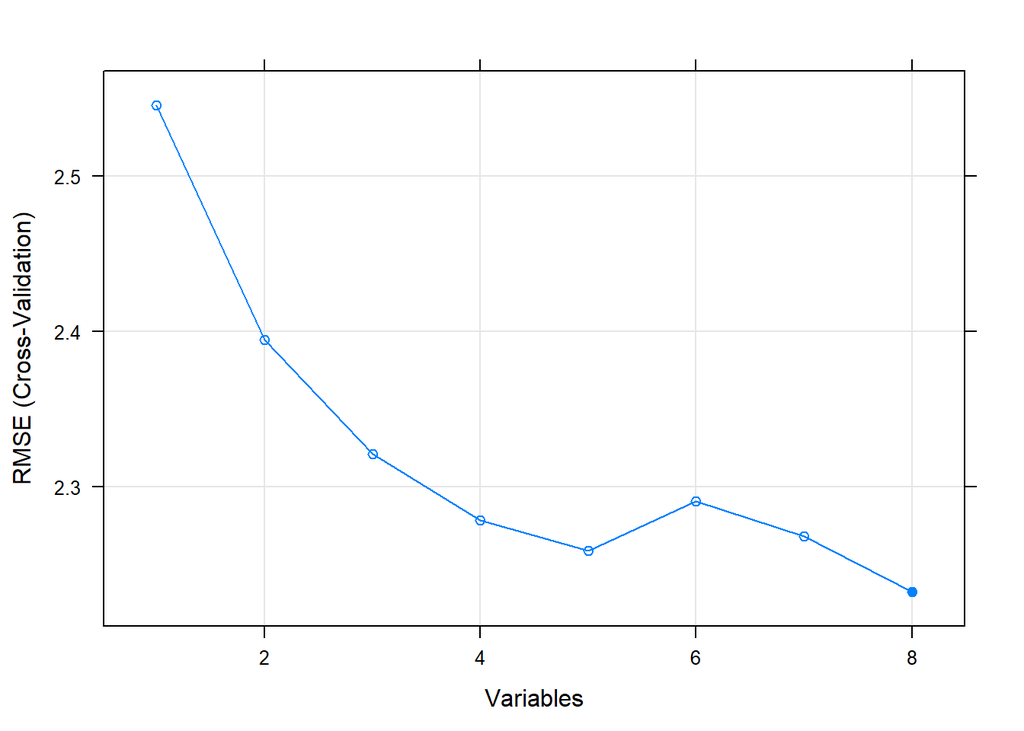

```r
plot(results, type=c("g", "o"))# ver nUmero optimo de variables con la que el modelo obtiene su mejor efectividad (accuracy)
```

```r
predictors(results)# lista de las variables elegidas, en orden de importancia
```

```
## [1] "MARCA"                      "PRESION_PTO_BAJO_FALLA"
## [3] "DIAMETRO"                   "DELTA_PRESION"
## [5] "CIRCUITO"                   "INDICE_CAVITACION_ESTIMADO"
## [7] "EDAD"                       "CONFIGURACION"
```

## 2. Porcentajes de contribución (%)

```r
#Optimizar el hiperparámetro de mtry: Nivel de profundidad
set.seed(1)
bestmtry <- tuneRF(x, y, stepFactor=1.5, improve=1e-5)
```

```
## mtry = 2  OOB error = 5.407695
## Searching left ...
## Searching right ...
## mtry = 3     OOB error = 5.480596
## -0.01348105 1e-05
```

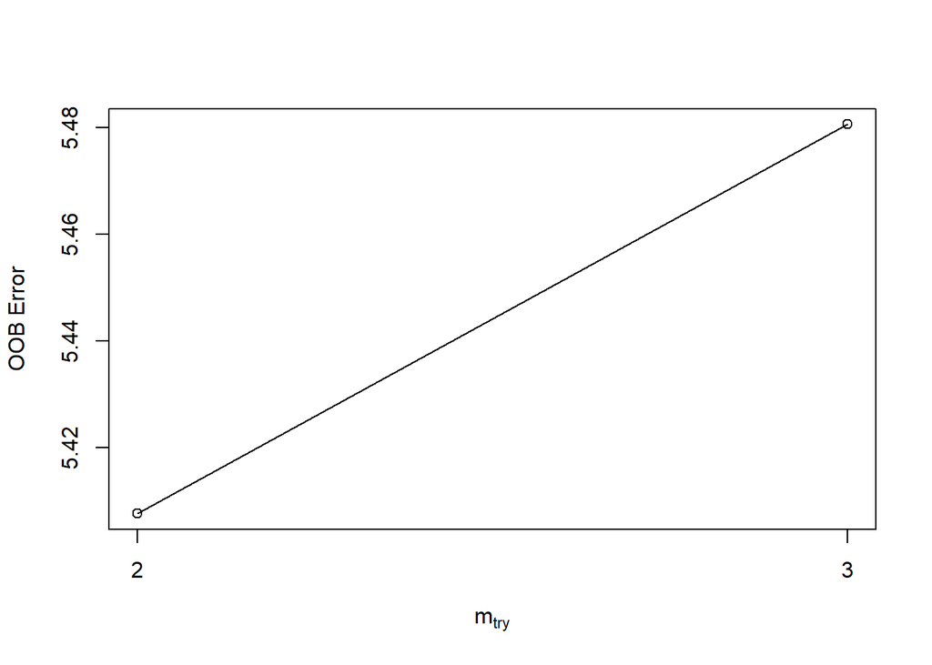

```r
#Ejecutar el modelo con el valor de mtry que se generO en el paso anterior
modelo_randforest <- randomForest(formula = NFALLA ~ . ,
                                  data = datos,
                                  mtry = 2,
                                  importance = TRUE,
                                  ntree = 1000)
```

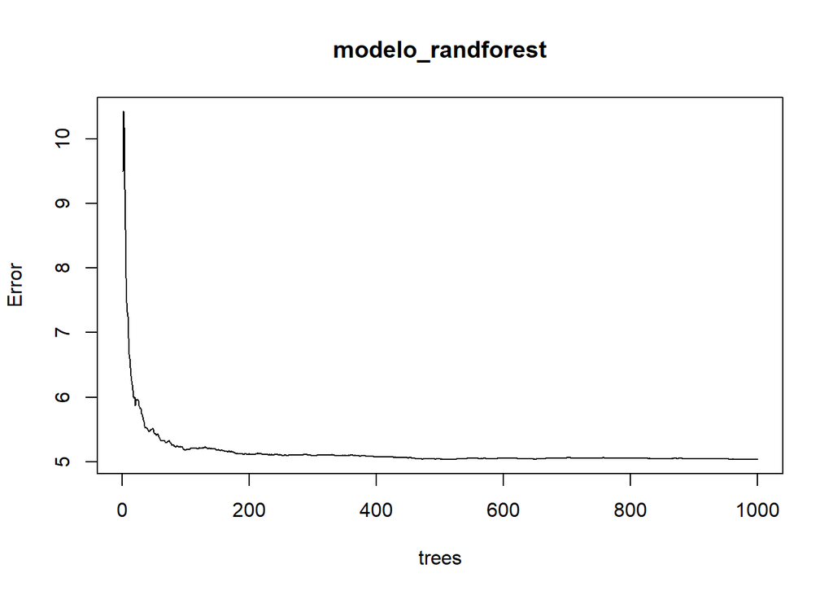

```r
plot(modelo_randforest)
```

```r
importancia <- as.data.frame(modelo_randforest$importance)
importancia <- rownames_to_column(importancia,var = "variable")
mse_pesos <- data.frame(importancia[,1],importancia[,2])
names(mse_pesos)<- c("Variable","MSE")
mse_pesos["Importancia (%) MSE"]<- (mse_pesos$MSE/sum(mse_pesos$MSE))*100
mse_pesos <- arrange(mse_pesos, -mse_pesos$`Importancia (%) MSE`)
mse_pesos
```

```
##                     Variable        MSE Importancia (%) MSE
## 1                      MARCA 0.66420501           18.658645
## 2              DELTA_PRESION 0.61831931           17.369637
## 3     PRESION_PTO_BAJO_FALLA 0.60066004           16.873559
## 4                   DIAMETRO 0.53015909           14.893068
## 5 INDICE_CAVITACION_ESTIMADO 0.41108167           11.547981
## 6                   CIRCUITO 0.40354879           11.336370
## 7                       EDAD 0.26303737            7.389166
## 8              CONFIGURACION 0.06875966            1.931575
```

[interactive chart not shown]

```r
modelo_randforest
```

```
##
## Call:
##  randomForest(formula = NFALLA ~ ., data = datos, mtry = 2, importance = TRUE,      ntree = 1000)
##                Type of random forest: regression
##                      Number of trees: 1000
## No. of variables tried at each split: 2
##
##           Mean of squared residuals: 5.03833
##                     % Var explained: 16.12
```

La efectividad del modelo cuando se tiene como variable objetivo a NFALLA (Número acumulado de fallas desde el 2015-2020) es de 16.12%, mientras que cuando se tiene como variable objetivo a la variable categórica falla la efectividad es del 67%

```r
accuracy_Test
```

```
## [1] 0.6750125
```

De acuerdo a lo anterior la metodología elegida es teniendo en cuenta a la variable objetivo categórica FALLA que representa si por lo menos la VRP ha fallado una vez o si por el contrario nunca ha fallado.

## Análisis descriptivo

El componente descriptivo tiene como objetivo principal informar que sucedió durante un periodo de análisis específico, debido a esta necesidad, este componente es principalmente gráfico. En este caso, se propone describir el desempeño asociado respecto a si ha o no ha fallado cada una de las VRP en el periodo comprendido desde el 2015 hasta el 2020, de acuerdo con las variables con que se finalizó el proceso de importancia de las variables.

### Fallas

[interactive chart not shown]

### Presión de punto bajo

[interactive chart not shown]

### Edad

[interactive chart not shown]

### Indice de cavitación

[interactive chart not shown]

### Delta de presión

[interactive chart not shown]

### Circuito

[interactive chart not shown]

### Marca

[interactive chart not shown]

### Diámetro

[interactive chart not shown]